# Классические_статистические_тесты.ДЗ

Anna Andreychenko

2024-11-15

# Гипотеза 1.

**Существует ассоциация между уровнем физической активности (бинарная переменная, физическая активность может быть ‘высокой’ и ‘низкой’) и частотой возникновения сердечно-сосудистых заболеваний у пациентов старше 50 лет. Попробуйте вариант с большими выборками (sample_size <- 100). Как изменится стратегия при малых выборках (sample_size <- 30) ?**

## Генерация данных

```r
# Воспроизводимость результатов
set.seed(42)

# Общий размер выборки
sample_size <- 100

# Генерация данных по физической активности (бинарная переменная) в фиксированном соотношении 1:1
#activity <- rbinom(sample_size, 1, 0.5)
activity100 <- c(rep(1, sample_size), rep(0, sample_size))

# Генерация данных по наличию сердечно-сосудистых заболеваний (бинарная переменная)
# У активных людей меньше вероятность заболеть (0.5 vs 0.6)

cardio100 <- c(rbinom(sample_size, 1, 0.5), rbinom(sample_size, 1, 0.6))

table(activity100, cardio100)
```

```
##            cardio100
## activity100  0  1
##           0 46 54
##           1 45 55
```

```r
#fisher.test(activity100, cardio100)
```

```r
# Воспроизводимость результатов
set.seed(42)

# Общий размер выборки
sample_size <- 30

# Генерация данных по физической активности (бинарная переменная) в фиксированном соотношении 1:1
activity30 <- c(rep(1, sample_size), rep(0, sample_size))

# Генерация данных по наличию сердечно-сосудистых заболеваний (бинарная переменная)
# У активных людей меньше вероятность заболеть (0.5 vs 0.6)

cardio30 <- c(rbinom(sample_size, 1, 0.5), rbinom(sample_size, 1, 0.6))

table(activity30, cardio30)
```

```
##           cardio30
## activity30  0  1
##          0 15 15
##          1 11 19
```

```r
#fisher.test(activity30, cardio30)
```

## Решение

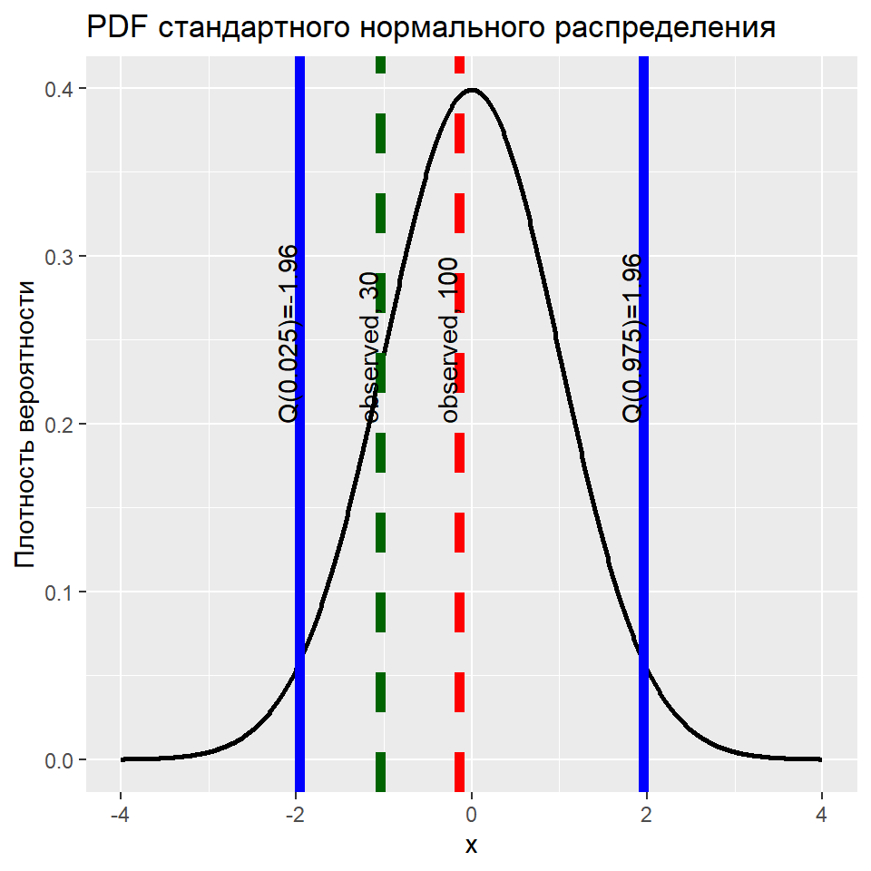

```r
# Функция для проведения z-теста для двух независимых долей
performTwoProportionZTest <- function(t) {

  x <- t[1,2]
  n1<- t[1,2]+t[1,1]

    y <- t[2,2]
  n2<- t[2,2]+t[2,1]

  # Расчет долей успешных исходов в выборках
  p1 <- x / n1
  p2 <- y / n2

  # Расчет объединенной доли успешных исходов
  P <- (x + y) / (n1 + n2)

  # Расчет стандартной ошибки
  SQ <- P * (1 - P) * (1/n1 + 1/n2)

  # Выполнение z-теста
  z_test_result <- (p1 - p2) / sqrt(SQ)

  return(z_test_result)
}

z_test_result100 <- performTwoProportionZTest(table(activity100,cardio100))
#print(z_test_result100)

z_test_result30 <- performTwoProportionZTest(table(activity30,cardio30))
#print(z_test_result30)


# Загрузка необходимого пакета ggplot2
library(ggplot2)


# Создание последовательности значений x
x_values <- seq(-4, 4, by = 0.01)

# Расчет значений Плотности Вероятности (PDF) для стандартного нормального распределения
pdf_normal <- dnorm(x_values, mean = 0, sd = 1)

# Квантили
quantiles <- c(0.025, 0.975)

quantile_values <- qnorm(quantiles, mean = 0, sd = 1)

# Создание данных для построения графика
pdf_data <- data.frame(x = x_values, Probability = pdf_normal)

# Создание графика PDF для визуализации стандартного нормального распределения
ggplot(pdf_data, aes(x = x)) +
  geom_line(aes(y = Probability), linewidth = 1, color = "black", linetype = "solid") +
  geom_vline(xintercept = quantile_values, linewidth = 2, linetype = "solid", color = "blue") +
  geom_vline(xintercept = z_test_result100, linewidth = 2, linetype = "dashed", color = "red") +
    geom_vline(xintercept = z_test_result30, linewidth = 2, linetype = "dashed", color = "darkgreen") +
  annotate("text", x = quantile_values[1]-0.15, y = 0.2, label = sprintf("Q(%.3f)=%.2f", quantiles[1], quantile_values[1]), hjust = 0, angle = 90) +
  annotate("text", x = quantile_values[2]-0.15, y = 0.2, label = sprintf("Q(%.3f)=%.2f", quantiles[2], quantile_values[2]), hjust = 0, angle = 90) +
  annotate("text", x = z_test_result100-0.15, y = 0.2, label = 'observed, 100', hjust = 0, angle = 90)+
  annotate("text", x = z_test_result30-0.15, y = 0.2, label = 'observed, 30', hjust = 0, angle = 90)+
  labs(title = "PDF стандартного нормального распределения", x = "x", y = "Плотность вероятности")
```

```r
p_value30 <- 2 * (1 - pnorm(abs(z_test_result30)))

p_value100 <- 2 * (1 - pnorm(abs(z_test_result100)))
```

## Ответ

1. H0: px=py Доли людей с ССЗ в группах равны.

   Ha: px!=py Доли людей с ССЗ в группах не равны.
2. Уровень значимости α: 0.05
3. Статистический тест (критерий): Z-критерий для разности долей (асимптотический) для обоих исследований (по 30 и 100 человек в каждой группе), т.к. число неуспехов и успехо везде превышает 5. Тест двусторонний.

```r
print(paste("4.  Критические значения статистики: ", round(quantile_values[1],2)," - ", round(quantile_values[2],2)))
```

```
## [1] "4.  Критические значения статистики:  -1.96  -  1.96"
```

```r
print(paste("5.1  Наблюдаемое значение статистики для выборки в 100:", round(z_test_result100,2)))
```

```
## [1] "5.1  Наблюдаемое значение статистики для выборки в 100: -0.14"
```

```r
print(paste("5.2  Наблюдаемое значение статистики для выборки в 30:", round(z_test_result30,2)))
```

```
## [1] "5.2  Наблюдаемое значение статистики для выборки в 30: -1.04"
```

```r
print(paste("6.1  p-value для выборки в 100:", round(p_value100,3)))
```

```
## [1] "6.1  p-value для выборки в 100: 0.887"
```

```r
print(paste("6.2  p-value для выборки в 30:", round(p_value30,3)))
```

```
## [1] "6.2  p-value для выборки в 30: 0.297"
```

6. Статистическая значимость: для обоих размеров выборки нулевую гипотезу не отвергаем.
7. Практическая значимость: выборки таких размеров не выявили статистически значимых различий в частотах возникновения ССЗ у лиц старше 50 лет имеющих высокую либо низкую физическую активность.

Если бы требовался точный тест, то нужно было бы применить тест Фишера для разницы долей.

# Гипотеза 2.

**Применение нового метода лечения для пациентов с артериальной гипертензией приведет к уменьшению среднего артериального давления по сравнению с пациентами, получающими стандартное лечение.**

## Генерация данных

```r
# Воспроизводимость результатов
set.seed(42)

# Размер выборки (в каждой группе)
sample_size <- 80

#Допустим стандартное отклонение артериального давления в генеральной совокупности
sd_gen = 10


# В популяции c экспериментальным методом лечения средний уровень систолического артериального давления меньше (130 vs 135 mm)
# Генерация данных для группы с новым методом лечения
group1 <- rnorm(sample_size, 130, sd_gen)  # экспериментальная группа

# Генерация данных для группы со стандартным лечением
group2 <- rnorm(sample_size, 135, sd_gen)  # контрольная группа
```

## Решение

```r
alpha=0.05
t_test <- t.test(group1, group2, var.equal = TRUE, alternative="less", conf.level=1-alpha)

# Квантили
quantiles <- c(0.05, 1)

df=sample_size+sample_size-2

t_critical_low <- qt(quantiles[1], df = df)
t_critical_up <-  qt(quantiles[2], df = df)
```

## Ответ

1. H0: mu1=mu2 средний уровень артериального давления в группах не отличается.

   Ha: mu1<mu2 средний уровень артериального давления в группе1 меньше, чем в группе 2(контроле).
2. Уровень значимости α: 0.05
3. Статистический тест (критерий): t-критерий для разницы средних для независимых выборок, т.к. у нас общая популяция, то считаем, что дисперсии в двух группах неизвестны, но равны. Тест левосторонний (left-tail test).

```r
print(paste("4.  Критическое значение статистики: ", round(t_critical_low,2)))
```

```
## [1] "4.  Критическое значение статистики:  -1.65"
```

```r
print(paste("5. Наблюдаемое значение статистики:", round(t_test$statistic,2)))
```

```
## [1] "5. Наблюдаемое значение статистики: -2.37"
```

```r
print(paste("6.  p-value:", format(t_test$p.value, scientific=T, digits=3)))
```

```
## [1] "6.  p-value: 9.45e-03"
```

```r
print(paste("ДИ:", round(t_test$conf.int[1],3), round(t_test$conf.int[2],3)))
```

```
## [1] "ДИ: -Inf -1.134"
```

6. Статистическая значимость: нулевую гипотезу отвергаем.
7. Практическая значимость: среднее значение АД в экcпериментальной группе стастистически значимо ниже на 3.7 единиц (95% односторонний ДИ: -Inf, -1.1), чем в контрольной. Необходима консультация мед эксперта является ли эта разница значимой с клинической точки зрения.

# Гипотеза 3.

**Внедрение программы реабилитации для пациентов с хронической болью в спине приведет к улучшению их физической активности (предположим что физическую активность можно оценить по шкале 0-100)**

## Генерация данных

```r
# Воспроизводимость результатов
set.seed(42)

# Размер выборки
sample_size <- 30

# В популяции до реабилитации средний уровень физической активности меньше (50 vs 60)
# Генерация данных до реабилитации
before <- rbinom(sample_size, 100, 0.5)

# Генерация данных после реабилитации
after <- rbinom(sample_size, 100, 0.6)
```

## Решение

```r
alpha <- 0.05
w_test <- wilcox.test(before, after, alternative = "less", paired = TRUE, conf.level = 1- alpha, conf.int = TRUE, exact=FALSE)

# Квантили
quantiles <- c(0.05, 1)

w_critical_low <- qbinom(quantiles[1], 100, 0.5)
w_critical_up <-  qbinom(quantiles[2], 100, 0.5)
```

## Ответ

1. H0: mu1=mu2 средний уровень физической активности у пациентов не изменился после реабилитации.

   Ha: mu1<mu2 средний уровень физической активности у пациентов повышается после реабилитации.
2. Уровень значимости α: 0.05.
3. Статистический тест (критерий): Выборки связанные и маленькие (30), поэтому будем применять непараметрический (ранговый) критерий Тест Манна-Уитни-Уилкоксона ддя связанных выборок, левосторонний.

```r
print(paste("4.  Критическое значение статистики: ", round(w_critical_low,2), "-", round(w_critical_up,2)))
```

```
## [1] "4.  Критическое значение статистики:  42 - 100"
```

```r
print(paste("5. Наблюдаемое значение статистики:", round(w_test$statistic,2)))
```

```
## [1] "5. Наблюдаемое значение статистики: 18.5"
```

```r
print(paste("6.  p-value:", format(w_test$p.value, scientific=T, digits=3)))
```

```
## [1] "6.  p-value: 5.58e-06"
```

```r
print(paste("ДИ:", round(w_test$conf.int[1],3), round(w_test$conf.int[2],3)))
```

```
## [1] "ДИ: -Inf -8.5"
```

6. Статистическая значимость: нулевую гипотезу отвергаем.
7. Практическая значимость: физическая активности повышается статистически значимо (медианное изменение 11, 95% односторониий ДИ: 8.5, Inf)) после реабилитации.

# Гипотеза 4.

**Применение нового метода лечения для пациентов с инфарктом миокарда увеличит долю вернувшихся к нормальной физической активности**

## Генерация данных

```r
# Воспроизводимость результатов
set.seed(42)

# Общий размер выборки
sample_size <- 200


# В популяции экспериментального лечения вероятность нормальной физической активности больше (0.7 vs 0.65)
# Генерация данных по статусу лечение (бинарная переменная, новый метод или стандарт) в фиксированном соотношении 1:1
treatment <- c(rep(1, sample_size), rep(0, sample_size))

# Генерация данных по физической активности после лечения (бинарная переменная)
activity <- c(rbinom(sample_size, 1, 0.7), rbinom(sample_size, 1, 0.65))

table(treatment, activity)
```

```
##          activity
## treatment   0   1
##         0  58 142
##         1  71 129
```

## Решение

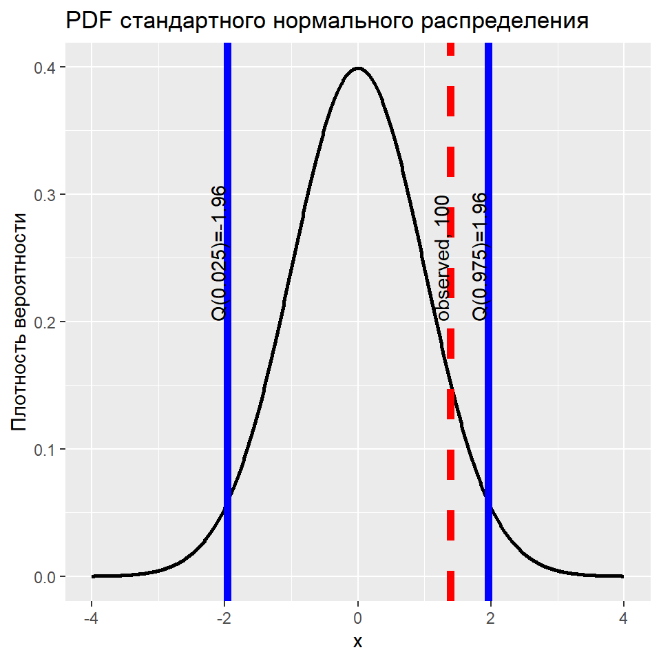

```r
z_test_result <- performTwoProportionZTest(table(treatment, activity))
# Создание последовательности значений x
x_values <- seq(-4, 4, by = 0.01)

# Расчет значений Плотности Вероятности (PDF) для стандартного нормального распределения
pdf_normal <- dnorm(x_values, mean = 0, sd = 1)

# Квантили
quantiles <- c(0.025, 0.975)

quantile_values <- qnorm(quantiles, mean = 0, sd = 1)

# Создание данных для построения графика
pdf_data <- data.frame(x = x_values, Probability = pdf_normal)

# Создание графика PDF для визуализации стандартного нормального распределения
ggplot(pdf_data, aes(x = x)) +
  geom_line(aes(y = Probability), linewidth = 1, color = "black", linetype = "solid") +
  geom_vline(xintercept = quantile_values, linewidth = 2, linetype = "solid", color = "blue") +
  geom_vline(xintercept = z_test_result, linewidth = 2, linetype = "dashed", color = "red") +
  annotate("text", x = quantile_values[1]-0.15, y = 0.2, label = sprintf("Q(%.3f)=%.2f", quantiles[1], quantile_values[1]), hjust = 0, angle = 90) +
  annotate("text", x = quantile_values[2]-0.15, y = 0.2, label = sprintf("Q(%.3f)=%.2f", quantiles[2], quantile_values[2]), hjust = 0, angle = 90) +
  annotate("text", x = z_test_result-0.15, y = 0.2, label = 'observed, 100', hjust = 0, angle = 90)+
  labs(title = "PDF стандартного нормального распределения", x = "x", y = "Плотность вероятности")
```

```r
p_value <- 2 * (1 - pnorm(abs(z_test_result)))
```

## Ответ

1. H0: px=py доля пациентов, вернувшихся к нормальной физической активности после экспериментального лечения, не изменилась по сравнению со стандартом.

   Ha: px!=py доли пациентов, вернувшихся к нормальной физической активности после экспериментального и стандартного лечения, не равны.
2. Уровень значимости α: 0.05.
3. Статистический тест (критерий): Z-критерий для разности долей для независимых выборок (асимтотический). Выбран асимптотический тест, потому что кол-во успеха и неуспеха превышает 5 в обеих группах. Тест двусторонний.

```r
print(paste("4.  Критические значения статистики: ", round(quantile_values[1],2)," - ", round(quantile_values[2],2)))
```

```
## [1] "4.  Критические значения статистики:  -1.96  -  1.96"
```

```r
print(paste("5.  Наблюдаемое значение статистики:", round(z_test_result,2)))
```

```
## [1] "5.  Наблюдаемое значение статистики: 1.39"
```

```r
print(paste("6.  p-value:", format(p_value, scientific=T, digits=3)))
```

```
## [1] "6.  p-value: 1.64e-01"
```

6. Статистическая значимость: нулевую гипотезу не отвергаем.
7. Практическая значимость: физическая активность среди пациентов с инфарктом миокарда не повышается статистически значимо после нового метода реабилитации по сравнению со стандартным методом (p> 0.05).

# Гипотеза 5.

**Применение медитации в течение 8 недель повлияет на наличие стресса (есть/нет) у лиц с высоким уровнем тревожности.**

## Генерация данных

```r
# Воспроизводимость результатов
set.seed(42)

# Размер выборки
sample_size <- 50

# Генерация данных до медитации (бинарная переменная) в фиксированном соотношении 1:1
before <- c(rep(1, sample_size), rep(0, sample_size))

# Генерация данных после медитации (бинарная переменная). После медитации вероятность наличия стресса меньше (0.2 vs 0.4)
after <- c(rbinom(2*sample_size, 1, 0.2))

table(after, before)
```

```
##      before
## after  0  1
##     0 45 32
##     1  5 18
```

## Решение

```r
# Значение нулевой гипотезы
p0 <- 0.5


# Рассчет стандартного отклонения
stdev <- sqrt(p0*(1-p0))

# Выполнение z-теста
z_test <- BSDA::z.test(after, mu = p0, alternative = "two.sided", sigma.x = stdev)

quantiles <- c(0.025, 0.975)

quantile_values <- qnorm(quantiles, mean = 0, sd = 1)
```

## Ответ

1. H0: p=0.5 Среди лиц с высоким уровнем тревожности доля лиц с наличием стресса после медитации равна 50%.

Гипотезы составлены на основе дизайна исследования. Исследование рандомизированное, набираются две группы по 50 человек с высоким уровнем тревожности, одна группа с наличием стресса, вторая группа без стресса.

2. Уровень значимости α: 0.05.
3. Статистический тест (критерий): Z-критерий для доли, т.к. количество успехов/неуспехов >=5. Двусторонний тест.

```r
print(paste("4.  Критические значения статистики: ", round(quantile_values[1],2)," - ", round(quantile_values[2],2)))
```

```
## [1] "4.  Критические значения статистики:  -1.96  -  1.96"
```

```r
print(paste("5.  Наблюдаемое значение статистики:", round(z_test$statistic,2)))
```

```
## [1] "5.  Наблюдаемое значение статистики: -5.4"
```

```r
print(paste("6.  p-value:", format(z_test$p.value, scientific=T,digits=3)))
```

```
## [1] "6.  p-value: 6.66e-08"
```

```r
print(paste("ДИ:", round(z_test$conf.int[1],3), round(z_test$conf.int[2],3)))
```

```
## [1] "ДИ: 0.132 0.328"
```

6. Статистическая значимость: нулевую гипотезу отвергаем.
7. Практическая значимость: Среди лиц с высоким уровнем тревожности доля лиц с наличием стресса после медитации 0.23 (95%ДИ: 0.13-0.33)

# Гипотеза 6.

**Применение альтернативного метода лечения для пациентов с биполярным расстройством приведет к значимому изменению уровня симптомов депрессии по отношению к группе, прошедшей стандартное лечение (депрессию можно определить по шкале от 0 до 100, при этом исследователь должен избегать любых предположений (кроме i.i.d.)).**

## Генерация данных

```r
# Воспроизводимость результатов
set.seed(42)

# Размер выборки для каждой группы
sample_size <- 20


# В популяции c экспериментальным методом лечения среднее депрессии меньше (55 vs 68)
# Генерация данных для экспериментальной группы
group1 <- rbinom(sample_size, 100, 0.55)  # экспериментальная группа

# Генерация данных для группы со стандартным лечением
group2 <- rbinom(sample_size, 100, 0.68)  # контрольная группа
```

## Решение

```r
alpha <- 0.05
w_test <- wilcox.test(group1, group2, alternative = "two.sided", paired = FALSE, conf.level = 1- alpha, conf.int = TRUE, exact=FALSE)

# Квантили
quantiles <- c(0.025, 0.975)

w_critical_low <- qbinom(quantiles[1], 100, 0.5)
w_critical_up <-  qbinom(quantiles[2], 100, 0.5)
```

## Ответ

1. H0: mu1=mu2 средний уровень депрессии в группах не отличается.

   Ha: mu1!=mu2 средний уровень депрессии в группе1 не равен среднему уровню депрессии в группе2.
2. Уровень значимости α: 0.05
3. Статистический тест (критерий): т.к. мы не имеем информации о форме распределения, кроме независимости и равенстве распределений, и выборка небольшая (20) выберем критерий Манна-Уитни-Уилкоксона для независимых выборок. Двусторонний тест.

```r
print(paste("4.  Критическое значение статистики: ", round(w_critical_low,2), "-", round(w_critical_up,2)))
```

```
## [1] "4.  Критическое значение статистики:  40 - 60"
```

```r
print(paste("5. Наблюдаемое значение статистики:", round(w_test$statistic,2)))
```

```
## [1] "5. Наблюдаемое значение статистики: 9"
```

```r
print(paste("6.  p-value:", format(w_test$p.value, scientific=T, digits=3)))
```

```
## [1] "6.  p-value: 2.44e-07"
```

```r
print(paste("ДИ:", round(w_test$conf.int[1],3), round(w_test$conf.int[2],3)))
```

```
## [1] "ДИ: -16 -10"
```

6. Статистическая значимость: нулевую гипотезу отвергаем.
7. Практическая значимость: средний уровень депрессии статистически значимо ниже на 13 (95% ДИ: 10-16) в группе, получавшей экспериментальное лечение, по сравнению с группой, получавшей стандартное лечение.

# Гипотеза 7.

**Длительность сна (в часах) ассоциирована с уровнем стресса у студентов (шкала с нормальным распределением)**

## Генерация данных

```r
library(mvtnorm) # библиотека mvtnorm для работы с многомерным нормальным распределением

# Воспроизводимость результатов
set.seed(42)

# Размер выборки
sample_size <- 100

# Средние значения для длительности сна (HoursOfSleep) и уровня стресса (StressLevel) в популяции
means <- c(7, 5)

# Матрица ковариации. В ислледуемой популяции HoursOfSleep и StressLevel ассоциированы отрицательно (r = -0.5)
cov_matrix <- matrix(c(1, -0.5, -0.5, 1), nrow = 2)

df <- rmvnorm(n = sample_size,
              mean = means,
              sigma = cov_matrix) %>%
      as_tibble() %>%
      setNames(c("HoursOfSleep", "StressLevel"))
```

## Решение (дополните решение визуализацией)

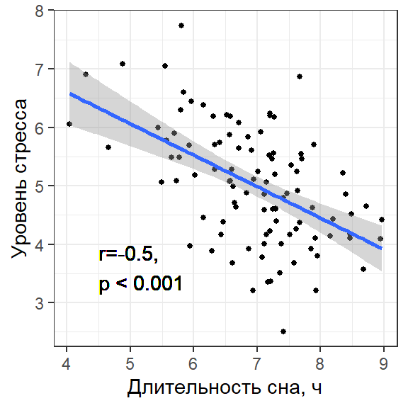

```r
library(ggplot2)
c_test <- cor.test(df$HoursOfSleep, df$StressLevel,
         alternative = c("two.sided"),
         method = c("pearson"),
         exact = NULL, conf.level = 0.95)

# Квантили
quantiles <- c(0.025, 0.975)

dff=sample_size-2

t_critical_low <- qt(quantiles[1], df = dff)
t_critical_up <-  qt(quantiles[2], df = dff)


ggplot(df, aes(x = HoursOfSleep, y = StressLevel)) +
    geom_point(size = 1.1)  +
    labs(x = "Длительность сна, ч",
         y = "Уровень стресса") +
    geom_text(x = 4.5,
              y = 4,
              label = "r=-0.5,\np < 0.001",
              hjust = 0,
              vjust = 1) +

    # Добавим линию регрессии

    geom_smooth(method = "lm") +

    # Поменяем оформление графика
    theme_bw()
```

## Ответ

1. H0: r=0 Длительность сна (в часах) не ассоциирована с уровенем стресса у студентов.

   Ha: r!=0 Длительность сна (в часах) ассоциирована с уровенем стресса у студентов.
2. Уровень значимости α: 0.05
3. Статистический тест (критерий): В качестве критерия будем использовать корреляцию Пирсона. Двусторонний тест.

```r
print(paste("4.  Критическое значение статистики: ", round(t_critical_low,2), "-", round(t_critical_up,2)))
```

```
## [1] "4.  Критическое значение статистики:  -1.98 - 1.98"
```

```r
print(paste("5. Наблюдаемое значение статистики:", round(c_test$statistic,2)))
```

```
## [1] "5. Наблюдаемое значение статистики: -6.06"
```

```r
print(paste("6.  p-value:", format(c_test$p.value, scientific=T, digits=3)))
```

```
## [1] "6.  p-value: 2.51e-08"
```

```r
print(paste("ДИ:", round(c_test$conf.int[1],3), round(c_test$conf.int[2],3)))
```

```
## [1] "ДИ: -0.652 -0.363"
```

6. Статистическая значимость: нулевую гипотезу отвергаем.
7. Практическая значимость: Длительность сна ассоциирована с уровнем стресса у студентов, коэффициент корреляции Пирсона = -0.52 (95%ДИ: [-0.65, -0.36]).